# Flexible Damage Functions

Author

James Rising, Sebastian Cadavid Sanchez, Climate Impact Lab

Published

April 30, 2026

## 0.1 Agriculture: Sorghum

Flexible damage function parameters at the Impact Region level.

**Change in sorghum yields (log change in yields) under full adaptation**

**Outcome units:** `physical`

$$D_{it} = (\alpha_i T_t + \beta_i T_t^2) \cdot Y_{it}^{\gamma}$$

where $\gamma$ is the income elasticity (fitted globally), $\alpha_i$ is the linear coefficient, and $\beta_i$ is the quadratic coefficient.

# 1 Global Estimation

## 1.1 Income Elasticity Estimation

The income elasticity $\gamma$ is estimated using a fixed-effects regression:

$$y_{it} = \gamma \cdot \log(Y_{it}) + \mu_{g(i,T)} + \nu_t + \varepsilon_{it}$$

where $\mu_{g(i,T)}$ are region-by-temperature-bin fixed effects and $\nu_t$ are year fixed effects.

Table 1: Income Elasticity (Gamma) Estimation Results

| Statistic | Value |
| --- | --- |
| Income elasticity ($\gamma$) | 0.0756 |
| Standard error | 2.39e-03 |
| 95% CI | [0.0709, 0.0803] |
| R-squared | 0.9581 |
| Observations | 24,681,159 |
| Regions | 24,326 |
| Gamma quantiles | 19 |

# 2 Parameter Distributions

## 2.1 8-Panel Summary

Row 1: gamma, alpha, beta, rsqr1. Row 2: rho, zeta, eta, rsqr2.

```
Using median gamma: 0.075590, 24,326 rows (of 462,194 total)
```

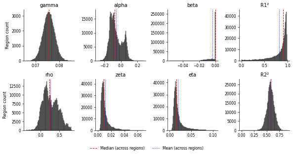

Figure 1: Distribution of Regional Parameters

## 2.2 Projection Equation and Parameter Definitions

The estimated parameters are used to project damages via Monte Carlo sampling:

$$D_{it}^k = (\hat{\alpha}_{ik} T_t + \hat{\beta}_{ik} T_t^2) Y_{it}^{\hat{\gamma}_k} + \hat{\theta}_{ik} T_t Y_{it}^{\hat{\gamma}_k} + \hat{\phi}_{it}^k$$

where $k$ indexes the Monte Carlo draw. The parameters in each row of the output CSV control distinct components of this equation:

- **gamma**: income elasticity $\hat{\gamma}_k$, one of 19 quantile values drawn from $N(\hat{\gamma}, SE(\hat{\gamma}))$
- **alpha, beta**: linear and quadratic temperature coefficients; $\hat{\alpha}_{ik}$ and $\hat{\beta}_{ik}$ are drawn from the joint normal defined by the VCV below
- **sigma11, sigma12, sigma22**: variance-covariance matrix of $(\alpha, \beta)$, used for joint uncertainty sampling
- **rho**: correlation between regional and global polynomial residuals $\rho_i$, used to maintain spatial covariance across regions in Monte Carlo draws
- **zeta**: temperature-dependent error scale $\zeta_{ik}$; the run-specific error term $\hat{\theta}_{ik}$ is drawn from $N(0, \zeta_{ik})$
- **eta**: residual noise standard deviation $\eta_{ik}$; the annual noise $\hat{\phi}_{it}^k$ is drawn from $N(0, \eta_{ik})$
- **rsqr1, rsqr2**: polynomial fit quality and error model fit, respectively

## 2.3 Summary Statistics

Table 2: Regional Parameter Summary

| Parameter | Mean | Median | Std | Min | Max | N |
| --- | --- | --- | --- | --- | --- | --- |
| alpha | -0.05696 | -0.07487 | 0.07426 | -0.2698 | 0.265 | 24,326 |
| beta | -0.0034 | 0 | 0.005043 | -0.05334 | 0 | 24,326 |
| rho | 0.2669 | 0.2379 | 0.206 | -0.3968 | 0.8389 | 24,324 |
| zeta | 0.01125 | 0.008924 | 0.007349 | 0 | 0.06731 | 24,326 |
| eta | 0.01954 | 0.01543 | 0.0126 | 0 | 0.1031 | 24,326 |
| rsqr1 | 0.8213 | 0.9049 | 0.1985 | 0 | 0.994 | 24,326 |
| rsqr2 | 0.5783 | 0.577 | 0.07281 | 0 | 0.9083 | 24,326 |

# 3 Spaghetti Curves

Regional damage function curves showing D(T) = αT + βT² for sampled regions.

[interactive chart not shown]

Figure 2: Regional Damage Functions

# 4 Zero Crossings

The zero crossing (extremum) of the parabola occurs at $T^* = -\alpha / (2\beta)$.

Table 3: Zero Crossing Statistics

| Category | Count | Percentage |
| --- | --- | --- |
| β = 0 (no crossing) | 13317 | 54.7% |
| T > 20°C (beyond graph) | 175 | 0.7% |
| T < 0°C (negative crossing) | 5535 | 22.8% |
| Valid crossings (0-20°C) | 5299 | 21.8% |

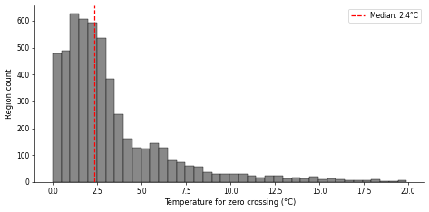

Figure 3: Distribution of Zero Crossing Temperatures

# 5 Slope Analysis

Maximum slope between 0 and 10°C: $\frac{dM}{dT} = \alpha + 2\beta T$

The maximum occurs at either T=0 or T=10 (endpoints of interval).

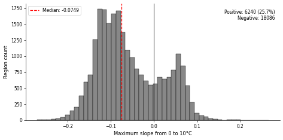

Figure 4: Distribution of Maximum Slopes (0-10°C)

*Convexity analysis omitted (beta constraint active).*

# 6 R-squared Analysis

## 6.1 Polynomial Fit Quality (rsqr1)

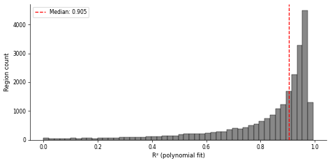

Figure 5: Regional Fit Quality (R-squared)

## 6.2 Error Model R-squared (rsqr2) Quantiles

Table 4: rsqr2 Quantiles

| 0% (Min) | 25% | 50% (Median) | 75% | 100% (Max) |
| --- | --- | --- | --- | --- |
| 0.0000 | 0.5329 | 0.5770 | 0.6238 | 0.9083 |

# 7 Modelled Variance

Modelled variance statistic: $1 - \frac{\sum_i \eta_i^2}{\sum_i D_i^2}$

Table 5: Modelled Variance Statistics

| Statistic | Value |
| --- | --- |
| Modelled variance | 0.9931 |
| Sum(η²) | 13.1462 |
| Sum(D²) at T=3.0°C | 1900.0062 |
| N regions | 24,326 |

# 8 Best- and Worst-Fitting Regions

The 3 worst- and 3 best-fitting regions by R-squared, with raw simulation data overlaid on the fitted polynomial curve. **Red rows = worst fits**, **green rows = best fits**.

Table 6: Best- and worst-fitting regions

Top 3 best fit (R²) Top 3 worst fit (R²)

| Region | α | β | η | R² |
| --- | --- | --- | --- | --- |
| GAB.5 | -0.0972 | -2.95e-4 | 0.00724 | 0.986 |
| GAB.2 | -0.0913 | -0.00101 | 0.0071 | 0.986 |
| IND.31.467.1884 | -0.0468 | -0.00269 | 0.00581 | 0.985 |
| LSO.R05bdde605ab49bd8 | 0.0053 | -0.00133 | 0.0277 | 0.00166 |
| SJM.2 | -3.43e-4 | -1.11e-4 | 0.0128 | 0.00278 |
| BOL.4.34.103 | 0.00213 | -1.97e-4 | 0.015 | 0.00327 |

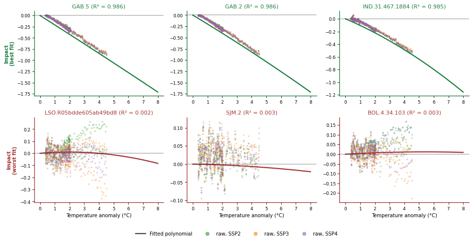

# 9 Regional Parameter Maps

Maps of key parameters at the **impact region** level. Red = negative (damage increases with T), Blue = positive.

## 9.1 Alpha (Linear Coefficient)

Alpha ($\alpha$) represents the linear sensitivity to temperature. Regions with negative alpha experience damage that increases with the first degree of warming.

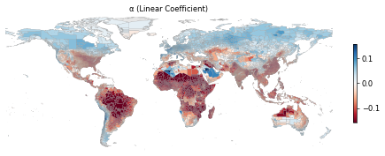

Figure 7: α (linear coefficient)

## 9.2 Beta (Quadratic Coefficient)

Beta ($\beta$) represents the curvature of the damage function.

The concavity ($\beta \leq 0$) constraint is enforced for this sector, meaning optimal temperature exists, damages accelerate beyond it.

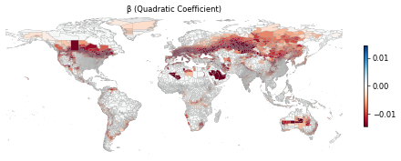

Figure 8: β (quadratic coefficient)

## 9.3 R-squared (Fit Quality)

$R^2$ measures the polynomial fit quality. Higher values indicate that the quadratic form captures more of the variance in the data.

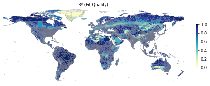

Figure 9: R² (stage 1 fit quality)

# 10 F2: Flex vs Raw Comparison

Comparison of flexible damage function predictions against raw simulation means.

For each scenario (RCP × SSP × Model), we compute at the final year:

- **Flex predicted**: $(\alpha \cdot T + \beta \cdot T^2) \cdot Y^\gamma$
- **Raw actual**: The outcome variable (y) from the source data

**Year 2098**: 292,536 rows

**rcp45**

**SSP2**

**high**

**Correlation:** 0.9036 | **RMSE:** 0.157451 | **Sign agreement:** 95.8%

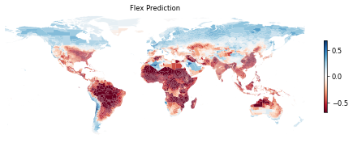

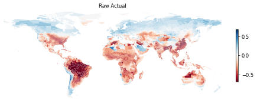

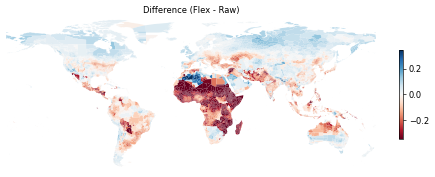

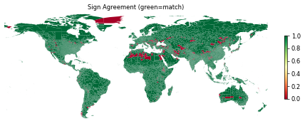

[interactive chart not shown]

Top 5 best predicted Top 5 worst predicted

Year 2098 · T<sub>mean</sub> across these regions: 2.05°C

| Region | Raw | Flex | Residual |
| --- | --- | --- | --- |
| FJI.R13886963f95ae1bc | 0 | 0 | 0 |
| TUV.R06fb643237e8113e | 0 | 0 | 0 |
| CHN.24.261.1753 | -0.611 | -0.611 | -1.45e-6 |
| RUS.72.2018.2135 | 0.101 | 0.101 | 1.55e-6 |
| IND.31.465.1876 | -0.202 | -0.202 | 3.45e-6 |
| ETH.2.12 | -0.3 | -1.22 | -0.915 |
| ETH.2.10.45 | -0.334 | -1.23 | -0.893 |
| ETH.2.10.R2ea9fc73b058b649 | -0.334 | -1.21 | -0.881 |
| ETH.9.46.404 | -0.337 | -1.22 | -0.878 |
| ETH.2.10.47 | -0.323 | -1.19 | -0.868 |

**low**

**Correlation:** 0.9458 | **RMSE:** 0.115310 | **Sign agreement:** 97.1%

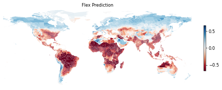

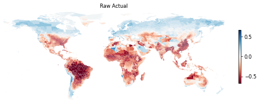

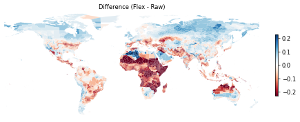

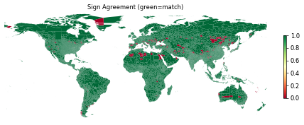

[interactive chart not shown]

Top 5 best predicted Top 5 worst predicted

Year 2098 · T<sub>mean</sub> across these regions: 2.05°C

| Region | Raw | Flex | Residual |
| --- | --- | --- | --- |
| FJI.R13886963f95ae1bc | 0 | 0 | 0 |
| TUV.R06fb643237e8113e | 0 | 0 | 0 |
| ARG.2.140 | -0.445 | -0.445 | 7.26e-6 |
| ARG.22.463 | -0.445 | -0.445 | 8.71e-6 |
| CHN.29.307.2122 | -0.211 | -0.211 | -1.28e-5 |
| AUS.6.483 | 0.294 | -0.377 | -0.671 |
| AUS.6.490 | 0.28 | -0.385 | -0.665 |
| AUS.6.484 | 0.302 | -0.36 | -0.662 |
| AUS.6.485 | 0.302 | -0.358 | -0.66 |
| AUS.6.488 | 0.31 | -0.341 | -0.651 |

**SSP3**

**high**

**Correlation:** 0.9589 | **RMSE:** 0.089441 | **Sign agreement:** 97.1%

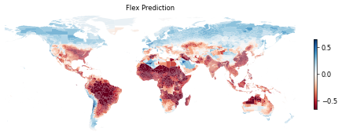

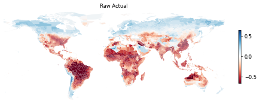

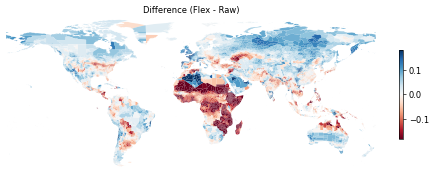

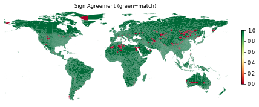

[interactive chart not shown]

Top 5 best predicted Top 5 worst predicted

Year 2098 · T<sub>mean</sub> across these regions: 2.05°C

| Region | Raw | Flex | Residual |
| --- | --- | --- | --- |
| FJI.R13886963f95ae1bc | 0 | 0 | 0 |
| TUV.R06fb643237e8113e | 0 | 0 | 0 |
| MEX.12.364 | -0.294 | -0.294 | 1.38e-6 |
| BGD.3.9.23.160 | -0.44 | -0.44 | 1.95e-6 |
| BRA.21.4016.7703 | -0.591 | -0.591 | 2.12e-6 |
| AUS.6.490 | 0.259 | -0.371 | -0.63 |
| AUS.6.483 | 0.265 | -0.364 | -0.629 |
| AUS.6.484 | 0.268 | -0.347 | -0.616 |
| AUS.6.485 | 0.267 | -0.345 | -0.613 |
| AUS.6.488 | 0.273 | -0.329 | -0.602 |

**low**

**Correlation:** 0.9690 | **RMSE:** 0.075008 | **Sign agreement:** 96.9%

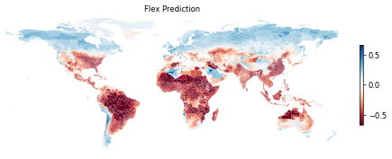

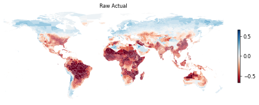

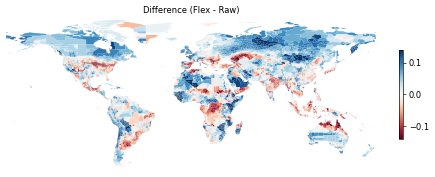

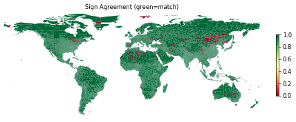

[interactive chart not shown]

Top 5 best predicted Top 5 worst predicted

Year 2098 · T<sub>mean</sub> across these regions: 2.05°C

| Region | Raw | Flex | Residual |
| --- | --- | --- | --- |
| FJI.R13886963f95ae1bc | 0 | 0 | 0 |
| TUV.R06fb643237e8113e | 0 | 0 | 0 |
| USA.28.1707 | -0.474 | -0.474 | -3.66e-7 |
| MEX.24.1266 | -0.479 | -0.479 | -1.40e-6 |
| USA.11.521 | -0.504 | -0.504 | 6.72e-6 |
| AUS.6.490 | 0.193 | -0.372 | -0.565 |
| AUS.6.483 | 0.195 | -0.364 | -0.56 |
| AUS.6.484 | 0.197 | -0.348 | -0.545 |
| AUS.6.485 | 0.196 | -0.346 | -0.542 |
| AUS.6.488 | 0.2 | -0.33 | -0.53 |

**SSP4**

**high**

**Correlation:** 0.9584 | **RMSE:** 0.096426 | **Sign agreement:** 96.6%

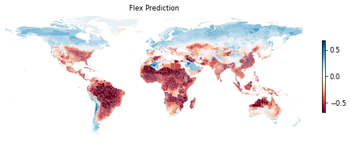

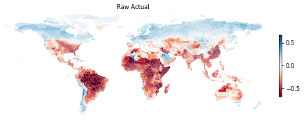

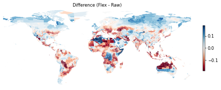

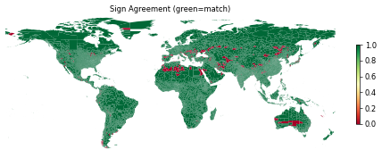

[interactive chart not shown]

Top 5 best predicted Top 5 worst predicted

Year 2098 · T<sub>mean</sub> across these regions: 2.05°C

| Region | Raw | Flex | Residual |
| --- | --- | --- | --- |
| FJI.R13886963f95ae1bc | 0 | 0 | 0 |
| TUV.R06fb643237e8113e | 0 | 0 | 0 |
| ARG.3.167 | -0.58 | -0.58 | 4.34e-6 |
| USA.34.1912 | -0.543 | -0.543 | -1.14e-5 |
| JOR.6.27 | -0.188 | -0.188 | -1.59e-5 |
| AUS.6.483 | 0.218 | -0.38 | -0.597 |
| AUS.6.484 | 0.228 | -0.363 | -0.591 |
| AUS.6.485 | 0.23 | -0.36 | -0.59 |
| AUS.6.490 | 0.199 | -0.388 | -0.587 |
| AUS.6.488 | 0.239 | -0.344 | -0.582 |

**low**

**Correlation:** 0.9677 | **RMSE:** 0.079510 | **Sign agreement:** 97.1%

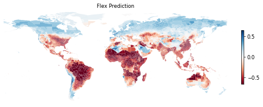

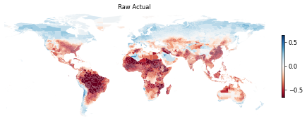

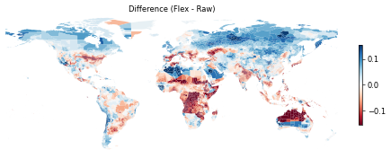

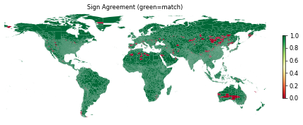

[interactive chart not shown]

Top 5 best predicted Top 5 worst predicted